# Human Variation and Race

## Before we begin, what do you think, now?

[interactive chart not shown]

## Sorting People by Physical Appearance

## Sorting People #1

**Classification**

- American Indian (AI)
- Asian (A)
- Black (B)
- Hispanic/Latino (HL)
- White (W)

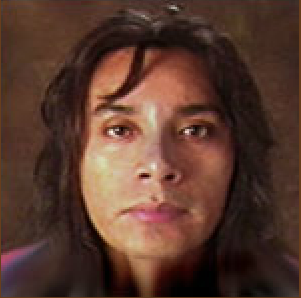

## Sorting People #1

**Classification**

- **American Indian (AI)**
- Asian (A)
- Black (B)
- Hispanic/Latino (HL)
- White (W)

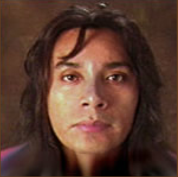

## Sorting People #2

**Classification**

- American Indian (AI)
- Asian (A)
- Black (B)
- Hispanic/Latino (HL)
- White (W)

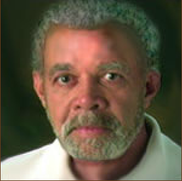

## Sorting People #2

**Classification**

- American Indian (AI)
- Asian (A)
- Black (B)
- **Hispanic/Latino (HL)**
- White (W)

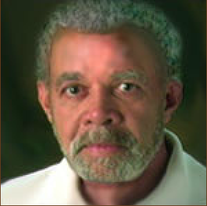

## Sorting People #3

**Classification**

- American Indian (AI)
- Asian (A)
- Black (B)
- Hispanic/Latino (HL)
- White (W)

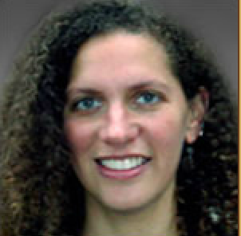

## Sorting People #3

**Classification**

- American Indian (AI)
- Asian (A)
- **Black (B)**
- Hispanic/Latino (HL)
- White (W)

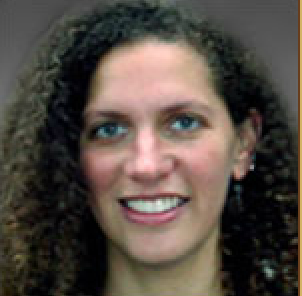

## Sorting People #4

**Classification**

- American Indian (AI)
- Asian (A)
- Black (B)
- Hispanic/Latino (HL)
- White (W)

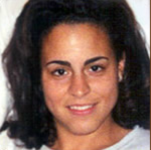

## Sorting People #4

**Classification**

- American Indian (AI)
- Asian (A)
- **Black (B)**
- Hispanic/Latino (HL)
- White (W)

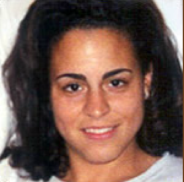

## Sorting People #5

**Classification**

- American Indian (AI)
- Asian (A)
- Black (B)
- Hispanic/Latino (HL)
- White (W)

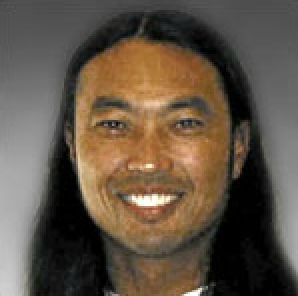

## Sorting People #5

**Classification**

- American Indian (AI)
- **Asian (A)**
- Black (B)
- Hispanic/Latino (HL)
- White (W)

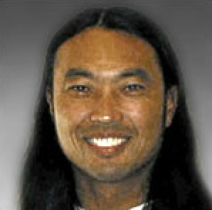

## Sorting People #6

**Classification**

- American Indian (AI)
- Asian (A)
- Black (B)
- Hispanic/Latino (HL)
- White (W)

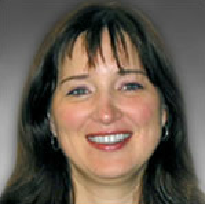

## Sorting People #6

**Classification**

- American Indian (AI)
- Asian (A)
- Black (B)
- **Hispanic/Latino (HL)**
- White (W)

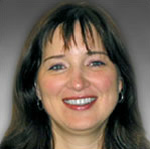

## Sorting People #7

**Classification**

- American Indian (AI)
- Asian (A)
- Black (B)
- Hispanic/Latino (HL)
- White (W)

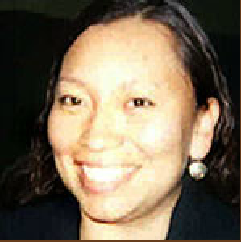

## Sorting People #7

**Classification**

- **American Indian (AI)**
- Asian (A)
- Black (B)
- Hispanic/Latino (HL)
- White (W)

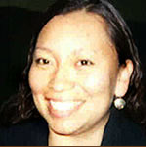

## Sorting People #8

**Classification**

- American Indian (AI)
- Asian (A)
- Black (B)
- Hispanic/Latino (HL)
- White (W)

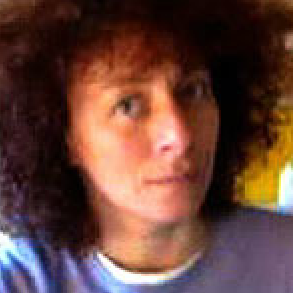

## Sorting People #8

**Classification**

- American Indian (AI)
- Asian (A)
- Black (B)
- Hispanic/Latino (HL)
- **White (W)**

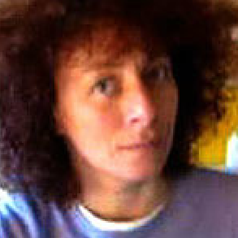

## Sorting People #9

**Classification**

- American Indian (AI)
- Asian (A)
- Black (B)
- Hispanic/Latino (HL)
- White (W)

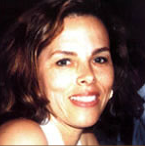

## Sorting People #9

**Classification**

- American Indian (AI)
- Asian (A)
- **Black (B)**
- Hispanic/Latino (HL)
- White (W)

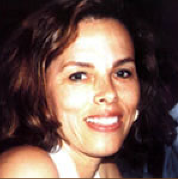

## Sorting People #10

**Classification**

- American Indian (AI)
- Asian (A)
- Black (B)
- Hispanic/Latino (HL)
- White (W)

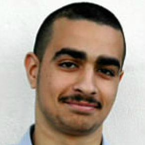

## Sorting People #10

**Classification**

- American Indian (AI)
- Asian (A)
- Black (B)
- Hispanic/Latino (HL)
- **White (W)**

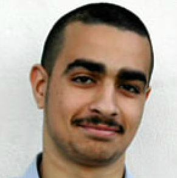

## Results & Discussion

## Racial Classification: Simple or Not So Much?

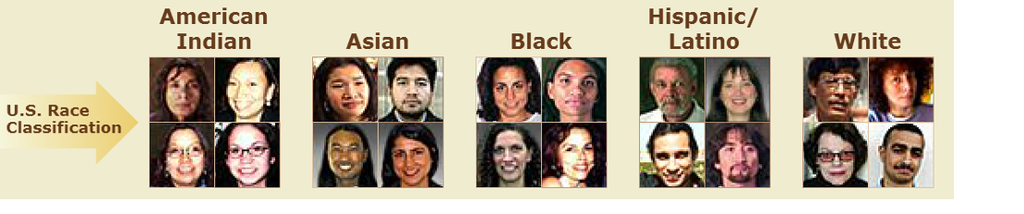

1. Calculate your percent correct/incorrect classification. **(1 minute)**
2. Share with your group. **(2 minutes)**
3. With group, come up with at least two reasons why *your* classification may not have matched a respondent's *self-classification*? **(2-3 minutes)**
4. Polls and discussion

## Final Thoughts & Questions

- Classifying people is a highly subjective process.
- Physical appearance may reveal very little about someone's ancestry or self-identity.
- Race must be recognized as a complex concept, with socio-cultural, historical, and biological components.

## A final exit poll…

[interactive chart not shown]

## More resources…

- [RACE: Are We So Different?](http://www.understandingrace.org/home.html)—A project of the American Anthropological Association
- [RACE: The Power of an Illusion](http://www.pbs.org/race/000_General/000_00-Home.htm)–More interactive activities, including "sorting" people.

## Thank you :-)